# IODS course project

## PCA on non standardized and standardized data

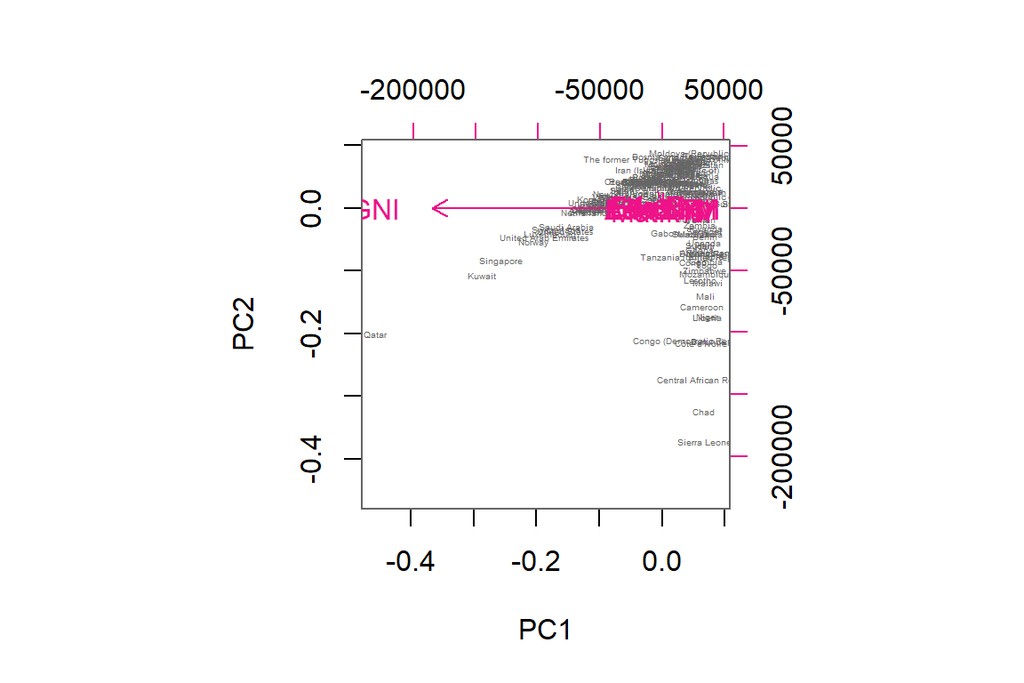

```r
library(GGally)
library(corrplot)

#filter out N/A-values
human <- filter(human, complete.cases(human))

# perform principal component analysis for non standardized data
pca_human <- prcomp(human)

# draw a biplot of the principal component representation and the original variables
biplot(pca_human, choices = 1:2, cex = c(0.3, 1), col = c("grey40", "deeppink2"))
```

```r
summary(pca_human)
```

```
## Importance of components:
##                              PC1      PC2   PC3   PC4   PC5   PC6    PC7    PC8
## Standard deviation     1.854e+04 185.5219 25.19 11.45 3.766 1.566 0.1912 0.1591
## Proportion of Variance 9.999e-01   0.0001  0.00  0.00 0.000 0.000 0.0000 0.0000
## Cumulative Proportion  9.999e-01   1.0000  1.00  1.00 1.000 1.000 1.0000 1.0000
```

```r
# standardize the variables
human_std <- scale(human)

# print out summaries of the standardized variables
summary(human_std)
```

```
##     Edu2.FM           Labo.FM           Edu.Exp           Life.Exp
##  Min.   :-2.8189   Min.   :-2.6247   Min.   :-2.7378   Min.   :-2.7188
##  1st Qu.:-0.5233   1st Qu.:-0.5484   1st Qu.:-0.6782   1st Qu.:-0.6425
##  Median : 0.3503   Median : 0.2316   Median : 0.1140   Median : 0.3056
##  Mean   : 0.0000   Mean   : 0.0000   Mean   : 0.0000   Mean   : 0.0000
##  3rd Qu.: 0.5958   3rd Qu.: 0.7350   3rd Qu.: 0.7126   3rd Qu.: 0.6717
##  Max.   : 2.6646   Max.   : 1.6632   Max.   : 2.4730   Max.   : 1.4218
##       GNI             Mat.Mor          Ado.Birth          Parli.F
##  Min.   :-0.9193   Min.   :-0.6992   Min.   :-1.1325   Min.   :-1.8203
##  1st Qu.:-0.7243   1st Qu.:-0.6496   1st Qu.:-0.8394   1st Qu.:-0.7409
##  Median :-0.3013   Median :-0.4726   Median :-0.3298   Median :-0.1403
##  Mean   : 0.0000   Mean   : 0.0000   Mean   : 0.0000   Mean   : 0.0000
##  3rd Qu.: 0.3712   3rd Qu.: 0.1932   3rd Qu.: 0.6030   3rd Qu.: 0.6127
##  Max.   : 5.6890   Max.   : 4.4899   Max.   : 3.8344   Max.   : 3.1850
```

```r
# perform principal component analysis (with the SVD method)
pca_human2 <- prcomp(human_std)
summary(pca_human2)
```

```
## Importance of components:
##                           PC1    PC2     PC3     PC4     PC5     PC6     PC7
## Standard deviation     2.0708 1.1397 0.87505 0.77886 0.66196 0.53631 0.45900
## Proportion of Variance 0.5361 0.1624 0.09571 0.07583 0.05477 0.03595 0.02634
## Cumulative Proportion  0.5361 0.6984 0.79413 0.86996 0.92473 0.96069 0.98702
##                            PC8
## Standard deviation     0.32224
## Proportion of Variance 0.01298
## Cumulative Proportion  1.00000
```

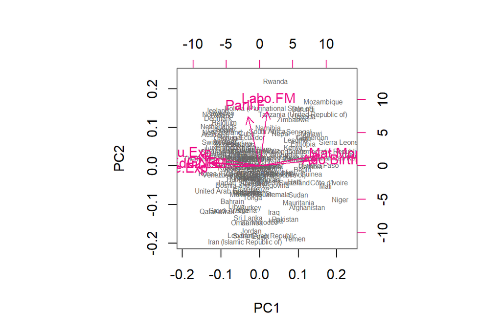

```r
# draw a biplot of the principal component representation
biplot(pca_human2, choices = 1:2, cex = c(0.5, 1), col = c("grey40", "deeppink2"))
```

## Interpretation of the PCA

- The PCA for both standardized and non-standanrdized data are represented above. In PCA similar countries cluster together (they have similar scores on the PCA components). And PCA can tell us what is the most valuable variable for clustering our data. “The length of the arrows approximates the variance of the variables, whereas the angels between them (cosine) approximate their correlations.”
- Results of these two models differ from each others significantly due to the different scaling of the variables. In the non-scaled model there were several zero-length arrows that were skipped and in the visualization and only GNI shows as a long single arrow. Without scaling most of the data is very far from the origin and can thus not be approximated by a (low dimension) linear subspace. Scaling (centering) is essential for PCA to give reasonable results.
- In our standardized model the porpotion of variance for PC1 is 0.536 and for PC2 0.162. Together they explain 0.698 of the total variance (the rest PC3-PC8 were less significant). The amount of componentes that explain 70-90 % of total variation of the original variables is usually considered appropriate in principal component analysis.
- Labo.FM and Parli.F are most important for explaining PC2, the rest were more important for explaining PC1.

## Multiple correspondence analysis (on tea dataset)

```r
#reading the data
library(dplyr)
library(tidyr)
library(ggplot2)
library(FactoMineR)
tea <- read.table("https://raw.githubusercontent.com/KimmoVehkalahti/Helsinki-Open-Data-Science/master/datasets/tea.csv", sep = ",", header = T)
# An option would have been to load: "tea <- read.csv("https://raw.githubusercontent.com/KimmoVehkalahti/Helsinki-Open-Data-Science/master/datasets/tea.csv", stringsAsFactors = TRUE)." This would also convert all the character variables of the data to factors (= R representation of categorical variables with 2 or more levels and labels). So you do NOT have to make  conversions one by one, e.g., tea$sugar <- factor(tea$sugar) etc. However I had already done the conversions, so I decided to go with the old version.


#defining the structure of the data
str(tea)
```

```
## 'data.frame':    300 obs. of  36 variables:
##  $ breakfast       : chr  "breakfast" "breakfast" "Not.breakfast" "Not.breakfast" ...
##  $ tea.time        : chr  "Not.tea time" "Not.tea time" "tea time" "Not.tea time" ...
##  $ evening         : chr  "Not.evening" "Not.evening" "evening" "Not.evening" ...
##  $ lunch           : chr  "Not.lunch" "Not.lunch" "Not.lunch" "Not.lunch" ...
##  $ dinner          : chr  "Not.dinner" "Not.dinner" "dinner" "dinner" ...
##  $ always          : chr  "Not.always" "Not.always" "Not.always" "Not.always" ...
##  $ home            : chr  "home" "home" "home" "home" ...
##  $ work            : chr  "Not.work" "Not.work" "work" "Not.work" ...
##  $ tearoom         : chr  "Not.tearoom" "Not.tearoom" "Not.tearoom" "Not.tearoom" ...
##  $ friends         : chr  "Not.friends" "Not.friends" "friends" "Not.friends" ...
##  $ resto           : chr  "Not.resto" "Not.resto" "resto" "Not.resto" ...
##  $ pub             : chr  "Not.pub" "Not.pub" "Not.pub" "Not.pub" ...
##  $ Tea             : chr  "black" "black" "Earl Grey" "Earl Grey" ...
##  $ How             : chr  "alone" "milk" "alone" "alone" ...
```

[output cut: 22 more lines]

```r
colnames(tea)
```

```
##  [1] "breakfast"        "tea.time"         "evening"          "lunch"
##  [5] "dinner"           "always"           "home"             "work"
##  [9] "tearoom"          "friends"          "resto"            "pub"
## [13] "Tea"              "How"              "sugar"            "how"
## [17] "where"            "price"            "age"              "sex"
## [21] "SPC"              "Sport"            "age_Q"            "frequency"
## [25] "escape.exoticism" "spirituality"     "healthy"          "diuretic"
## [29] "friendliness"     "iron.absorption"  "feminine"         "sophisticated"
## [33] "slimming"         "exciting"         "relaxing"         "effect.on.health"
```

```r
# View(tea)
summary(tea)
```

```
##   breakfast           tea.time           evening             lunch
##  Length:300         Length:300         Length:300         Length:300
##  Class :character   Class :character   Class :character   Class :character
##  Mode  :character   Mode  :character   Mode  :character   Mode  :character
##
##
##
##     dinner             always              home               work
##  Length:300         Length:300         Length:300         Length:300
##  Class :character   Class :character   Class :character   Class :character
##  Mode  :character   Mode  :character   Mode  :character   Mode  :character
##
##
##
##    tearoom            friends             resto               pub
##  Length:300         Length:300         Length:300         Length:300
##  Class :character   Class :character   Class :character   Class :character
##  Mode  :character   Mode  :character   Mode  :character   Mode  :character
##
##
##
##      Tea                How               sugar               how
##  Length:300         Length:300         Length:300         Length:300
##  Class :character   Class :character   Class :character   Class :character
##  Mode  :character   Mode  :character   Mode  :character   Mode  :character
##
##
##
##     where              price                age            sex
##  Length:300         Length:300         Min.   :15.00   Length:300
##  Class :character   Class :character   1st Qu.:23.00   Class :character
##  Mode  :character   Mode  :character   Median :32.00   Mode  :character
##                                        Mean   :37.05
##                                        3rd Qu.:48.00
##                                        Max.   :90.00
##      SPC               Sport              age_Q            frequency
##  Length:300         Length:300         Length:300         Length:300
##  Class :character   Class :character   Class :character   Class :character
##  Mode  :character   Mode  :character   Mode  :character   Mode  :character
##
```

[output cut: 8 more lines]

```
##
##  friendliness       iron.absorption      feminine         sophisticated
##  Length:300         Length:300         Length:300         Length:300
##  Class :character   Class :character   Class :character   Class :character
##  Mode  :character   Mode  :character   Mode  :character   Mode  :character
##
##
##
##    slimming           exciting           relaxing         effect.on.health
##  Length:300         Length:300         Length:300         Length:300
##  Class :character   Class :character   Class :character   Class :character
##  Mode  :character   Mode  :character   Mode  :character   Mode  :character
##
##
##
```

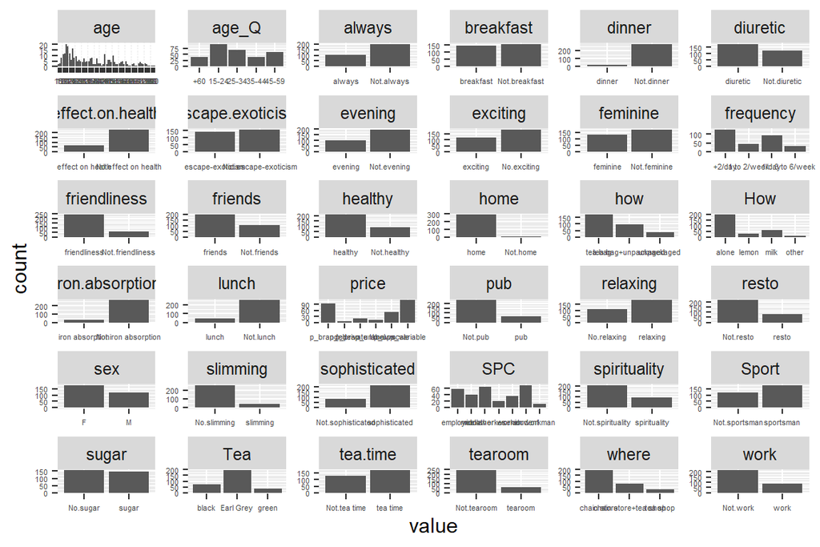

```r
#convert to factors
tea$sugar <- factor(tea$sugar)
tea$breakfast <- factor(tea$breakfast)
tea$tea.time <- factor(tea$tea.time)
tea$evening <- factor(tea$evening)
tea$lunch <- factor(tea$lunch)
tea$dinner <- factor(tea$dinner)
tea$always <- factor(tea$always)
tea$home <- factor(tea$home)
tea$work <- factor(tea$work)
tea$age <- factor(tea$age)
tea$tearoom <- factor(tea$tearoom)
tea$friends <- factor(tea$friends)
tea$resto <- factor(tea$resto)
tea$pub <- factor(tea$pub)
tea$how <- factor(tea$how)
tea$where <- factor(tea$where)
tea$Tea <- factor(tea$Tea)
tea$price <- factor(tea$price)
tea$sex <- factor(tea$sex)
tea$SPC <- factor(tea$SPC)
tea$Sport <- factor(tea$Sport)
tea$age_Q <- factor(tea$age_Q)
tea$frequency <- factor(tea$frequency)
tea$escape.exoticism <- factor(tea$escape.exoticism)
tea$spirituality <- factor(tea$spirituality)
tea$healthy <- factor(tea$healthy)
tea$diuretic <- factor(tea$diuretic)
tea$friendliness <- factor(tea$friendliness)
tea$iron.absorption <- factor(tea$iron.absorption)
tea$feminine <- factor(tea$feminine)
tea$sophisticated <- factor(tea$sophisticated)
tea$slimming <- factor(tea$slimming)
tea$exciting <- factor(tea$exciting)
tea$relaxing <- factor(tea$relaxing)
tea$effect.on.health <- factor(tea$effect.on.health)


# filter out all rows with NA values
tea_ <- filter(tea, complete.cases(tea))

#create a smaller dataset
#keep_columns <- c("age_Q", "sex","breakfast", "dinner", "evening", "Tea", "how", "sugar", "where", "How", "friends")

#teaS <- select(tea, all_of(keep_columns))


# Plot
pivot_longer(tea_, cols = everything()) %>%
  ggplot(aes(value)) + facet_wrap("name", scales = "free") + geom_bar() + theme(axis.text=element_text(size=4))
```

```r
#MCA analysis
mca <- MCA(tea_, graph = FALSE)
mca2 <- MCA(tea_[1:10], graph = FALSE)

# summary of the MCA model
summary(mca)
```

```
##
## Call:
## MCA(X = tea_, graph = FALSE)
##
##
## Eigenvalues
##                        Dim.1   Dim.2   Dim.3   Dim.4   Dim.5   Dim.6   Dim.7
## Variance               0.102   0.096   0.085   0.076   0.066   0.065   0.063
## % of var.              3.217   3.038   2.686   2.413   2.083   2.063   2.003
## Cumulative % of var.   3.217   6.255   8.941  11.353  13.436  15.499  17.502
##                        Dim.8   Dim.9  Dim.10  Dim.11  Dim.12  Dim.13  Dim.14
## Variance               0.060   0.056   0.055   0.052   0.050   0.049   0.047
## % of var.              1.890   1.755   1.732   1.651   1.594   1.542   1.496
## Cumulative % of var.  19.392  21.147  22.879  24.530  26.124  27.666  29.162
##                       Dim.15  Dim.16  Dim.17  Dim.18  Dim.19  Dim.20  Dim.21
## Variance               0.047   0.046   0.044   0.044   0.043   0.041   0.040
## % of var.              1.481   1.444   1.403   1.376   1.349   1.297   1.266
## Cumulative % of var.  30.643  32.088  33.491  34.867  36.216  37.512  38.778
##                       Dim.22  Dim.23  Dim.24  Dim.25  Dim.26  Dim.27  Dim.28
## Variance               0.040   0.039   0.039   0.037   0.037   0.036   0.036
## % of var.              1.250   1.221   1.218   1.181   1.155   1.146   1.142
## Cumulative % of var.  40.028  41.249  42.467  43.648  44.802  45.948  47.090
##                       Dim.29  Dim.30  Dim.31  Dim.32  Dim.33  Dim.34  Dim.35
## Variance               0.035   0.035   0.035   0.033   0.033   0.033   0.033
## % of var.              1.115   1.104   1.090   1.053   1.042   1.038   1.026
## Cumulative % of var.  48.206  49.310  50.400  51.452  52.494  53.533  54.559
##                       Dim.36  Dim.37  Dim.38  Dim.39  Dim.40  Dim.41  Dim.42
## Variance               0.032   0.031   0.031   0.030   0.030   0.030   0.030
## % of var.              1.001   0.985   0.978   0.957   0.951   0.943   0.940
## Cumulative % of var.  55.560  56.545  57.523  58.480  59.430  60.374  61.314
##                       Dim.43  Dim.44  Dim.45  Dim.46  Dim.47  Dim.48  Dim.49
## Variance               0.030   0.029   0.029   0.029   0.029   0.029   0.028
## % of var.              0.935   0.922   0.920   0.915   0.909   0.906   0.896
## Cumulative % of var.  62.249  63.171  64.091  65.006  65.915  66.821  67.717
##                       Dim.50  Dim.51  Dim.52  Dim.53  Dim.54  Dim.55  Dim.56
## Variance               0.028   0.028   0.028   0.028   0.028   0.028   0.028
## % of var.              0.891   0.886   0.885   0.884   0.880   0.877   0.877
## Cumulative % of var.  68.608  69.494  70.379  71.263  72.142  73.020  73.897
##                       Dim.57  Dim.58  Dim.59  Dim.60  Dim.61  Dim.62  Dim.63
## Variance               0.028   0.028   0.028   0.028   0.027   0.026   0.026
```

[output cut: 80 more lines]

```
## dinner         0.339  0.263  0.009  1.609 |
## Not.dinner    -0.026  0.020  0.009 -1.609 |
##
## Categorical variables (eta2)
##                 Dim.1 Dim.2 Dim.3
## breakfast     | 0.007 0.014 0.002 |
## tea.time      | 0.050 0.185 0.000 |
## evening       | 0.034 0.071 0.043 |
## lunch         | 0.001 0.071 0.004 |
## dinner        | 0.035 0.051 0.009 |
## always        | 0.010 0.070 0.012 |
## home          | 0.007 0.019 0.012 |
## work          | 0.001 0.052 0.137 |
## tearoom       | 0.114 0.175 0.065 |
## friends       | 0.002 0.218 0.032 |
```

```r
# define eigenvalues and visualize the MCA model
#install.packages("FactoMineR")
#install.packages("factoextra")

library(FactoMineR)
library(factoextra)
```

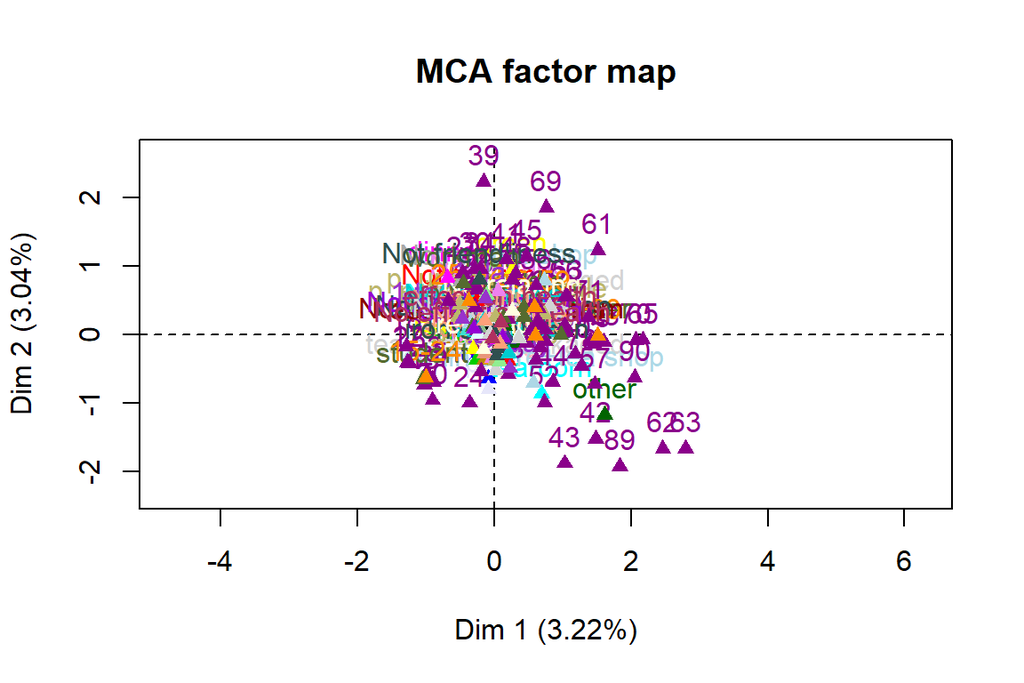

```r
plot(mca, invisible=c("ind"), habillage = "quali", graph.type = "classic")
```

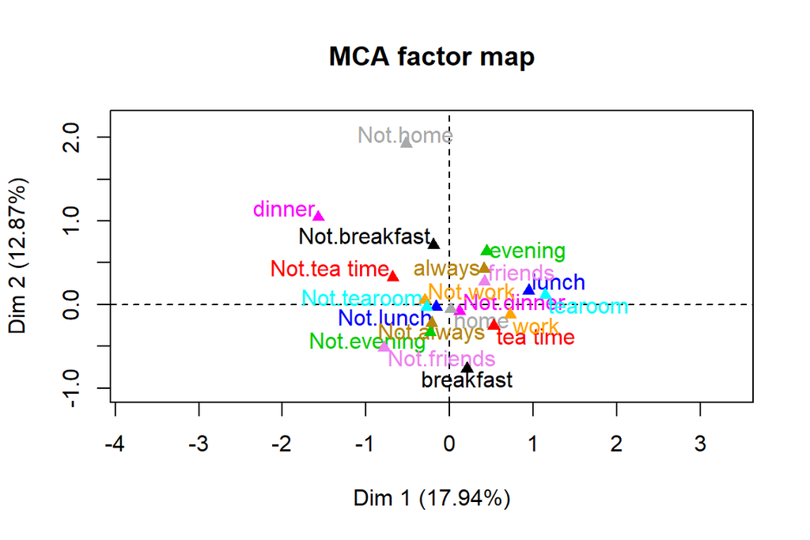

```r
plot(mca2, invisible=c("ind"), habillage = "quali", graph.type = "classic")
```

```r
get_eig(mca)
```

```
##           eigenvalue variance.percent cumulative.variance.percent
## Dim.1   1.018561e-01     3.216507e+00                    3.216507
## Dim.2   9.620603e-02     3.038085e+00                    6.254592
## Dim.3   8.505861e-02     2.686061e+00                    8.940653
## Dim.4   7.640089e-02     2.412660e+00                   11.353313
## Dim.5   6.596636e-02     2.083148e+00                   13.436461
## Dim.6   6.532495e-02     2.062893e+00                   15.499354
## Dim.7   6.342929e-02     2.003030e+00                   17.502384
## Dim.8   5.985231e-02     1.890073e+00                   19.392457
## Dim.9   5.556511e-02     1.754688e+00                   21.147145
## Dim.10  5.484243e-02     1.731866e+00                   22.879012
## Dim.11  5.228457e-02     1.651092e+00                   24.530103
## Dim.12  5.046655e-02     1.593680e+00                   26.123784
## Dim.13  4.884469e-02     1.542464e+00                   27.666247
## Dim.14  4.737656e-02     1.496102e+00                   29.162349
## Dim.15  4.689387e-02     1.480859e+00                   30.643208
## Dim.16  4.573735e-02     1.444338e+00                   32.087546
## Dim.17  4.442745e-02     1.402972e+00                   33.490518
## Dim.18  4.357542e-02     1.376066e+00                   34.866584
## Dim.19  4.272433e-02     1.349189e+00                   36.215773
## Dim.20  4.106023e-02     1.296639e+00                   37.512412
## Dim.21  4.008107e-02     1.265718e+00                   38.778130
## Dim.22  3.957598e-02     1.249768e+00                   40.027898
## Dim.23  3.865791e-02     1.220776e+00                   41.248674
## Dim.24  3.857483e-02     1.218153e+00                   42.466826
## Dim.25  3.738892e-02     1.180703e+00                   43.647529
## Dim.26  3.656722e-02     1.154754e+00                   44.802283
## Dim.27  3.629672e-02     1.146212e+00                   45.948496
## Dim.28  3.616251e-02     1.141974e+00                   47.090469
## Dim.29  3.532293e-02     1.115461e+00                   48.205930
## Dim.30  3.495839e-02     1.103949e+00                   49.309880
## Dim.31  3.450661e-02     1.089682e+00                   50.399562
## Dim.32  3.333807e-02     1.052781e+00                   51.452343
## Dim.33  3.300131e-02     1.042147e+00                   52.494490
## Dim.34  3.287106e-02     1.038034e+00                   53.532523
## Dim.35  3.250206e-02     1.026381e+00                   54.558904
## Dim.36  3.168907e-02     1.000707e+00                   55.559611
## Dim.37  3.120312e-02     9.853618e-01                   56.544973
## Dim.38  3.097282e-02     9.780890e-01                   57.523062
## Dim.39  3.029592e-02     9.567131e-01                   58.479775
```

[output cut: 60 more lines]

```
## Dim.100 8.033550e-03     2.536911e-01                   98.139530
## Dim.101 7.765661e-03     2.452314e-01                   98.384762
## Dim.102 7.564226e-03     2.388703e-01                   98.623632
## Dim.103 6.738516e-03     2.127952e-01                   98.836427
## Dim.104 6.434357e-03     2.031902e-01                   99.039618
## Dim.105 6.307963e-03     1.991988e-01                   99.238816
## Dim.106 5.902794e-03     1.864040e-01                   99.425220
## Dim.107 5.220109e-03     1.648455e-01                   99.590066
## Dim.108 5.054306e-03     1.596097e-01                   99.749676
## Dim.109 4.280263e-03     1.351662e-01                   99.884842
## Dim.110 3.646675e-03     1.151582e-01                  100.000000
## Dim.111 2.451623e-31     7.741969e-30                  100.000000
## Dim.112 1.523961e-31     4.812507e-30                  100.000000
## Dim.113 8.050419e-32     2.542238e-30                  100.000000
## Dim.114 4.980390e-32     1.572755e-30                  100.000000
```

```r
get_eigenvalue(mca)
```

```
##           eigenvalue variance.percent cumulative.variance.percent
## Dim.1   1.018561e-01     3.216507e+00                    3.216507
## Dim.2   9.620603e-02     3.038085e+00                    6.254592
## Dim.3   8.505861e-02     2.686061e+00                    8.940653
## Dim.4   7.640089e-02     2.412660e+00                   11.353313
## Dim.5   6.596636e-02     2.083148e+00                   13.436461
## Dim.6   6.532495e-02     2.062893e+00                   15.499354
## Dim.7   6.342929e-02     2.003030e+00                   17.502384
## Dim.8   5.985231e-02     1.890073e+00                   19.392457
## Dim.9   5.556511e-02     1.754688e+00                   21.147145
## Dim.10  5.484243e-02     1.731866e+00                   22.879012
## Dim.11  5.228457e-02     1.651092e+00                   24.530103
## Dim.12  5.046655e-02     1.593680e+00                   26.123784
## Dim.13  4.884469e-02     1.542464e+00                   27.666247
## Dim.14  4.737656e-02     1.496102e+00                   29.162349
## Dim.15  4.689387e-02     1.480859e+00                   30.643208
## Dim.16  4.573735e-02     1.444338e+00                   32.087546
## Dim.17  4.442745e-02     1.402972e+00                   33.490518
## Dim.18  4.357542e-02     1.376066e+00                   34.866584
## Dim.19  4.272433e-02     1.349189e+00                   36.215773
## Dim.20  4.106023e-02     1.296639e+00                   37.512412
## Dim.21  4.008107e-02     1.265718e+00                   38.778130
## Dim.22  3.957598e-02     1.249768e+00                   40.027898
## Dim.23  3.865791e-02     1.220776e+00                   41.248674
## Dim.24  3.857483e-02     1.218153e+00                   42.466826
## Dim.25  3.738892e-02     1.180703e+00                   43.647529
## Dim.26  3.656722e-02     1.154754e+00                   44.802283
## Dim.27  3.629672e-02     1.146212e+00                   45.948496
## Dim.28  3.616251e-02     1.141974e+00                   47.090469
## Dim.29  3.532293e-02     1.115461e+00                   48.205930
## Dim.30  3.495839e-02     1.103949e+00                   49.309880
## Dim.31  3.450661e-02     1.089682e+00                   50.399562
## Dim.32  3.333807e-02     1.052781e+00                   51.452343
## Dim.33  3.300131e-02     1.042147e+00                   52.494490
## Dim.34  3.287106e-02     1.038034e+00                   53.532523
## Dim.35  3.250206e-02     1.026381e+00                   54.558904
## Dim.36  3.168907e-02     1.000707e+00                   55.559611
## Dim.37  3.120312e-02     9.853618e-01                   56.544973
## Dim.38  3.097282e-02     9.780890e-01                   57.523062
## Dim.39  3.029592e-02     9.567131e-01                   58.479775
```

[output cut: 60 more lines]

```
## Dim.100 8.033550e-03     2.536911e-01                   98.139530
## Dim.101 7.765661e-03     2.452314e-01                   98.384762
## Dim.102 7.564226e-03     2.388703e-01                   98.623632
## Dim.103 6.738516e-03     2.127952e-01                   98.836427
## Dim.104 6.434357e-03     2.031902e-01                   99.039618
## Dim.105 6.307963e-03     1.991988e-01                   99.238816
## Dim.106 5.902794e-03     1.864040e-01                   99.425220
## Dim.107 5.220109e-03     1.648455e-01                   99.590066
## Dim.108 5.054306e-03     1.596097e-01                   99.749676
## Dim.109 4.280263e-03     1.351662e-01                   99.884842
## Dim.110 3.646675e-03     1.151582e-01                  100.000000
## Dim.111 2.451623e-31     7.741969e-30                  100.000000
## Dim.112 1.523961e-31     4.812507e-30                  100.000000
## Dim.113 8.050419e-32     2.542238e-30                  100.000000
## Dim.114 4.980390e-32     1.572755e-30                  100.000000
```

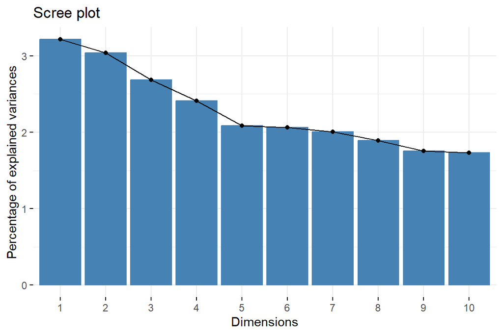

```r
fviz_eig(mca)
```

In the MCA model including all the variables(mca), the first dimension explained only 3,2 % % the total variance (inertia). Only when reaching the dimension 52, the model explains 70 % of total variance. The MCA plot is very messy and hard to read because it has so many variables (and it plots every level of the categorial variables eg. both dinner and Not.dinner). It gets much more easier to read when including only the ten first variables (mca2), and in this model the first dimension explains 17,94 % of the variance.